# Лабораторная работа №10

Администрирование сетевых подсистем

Иванов Сергей Владимирович, НПИбд-01-23

Российский университет дружбы народов, Москва, Россия

27 октября 2025

# Цель работы

Приобретение практических навыков по конфигурированию SMTP-сервера в части настройки аутентификации.

# Задание

1. Настройте Dovecot для работы с LMTP
2. Настройте аутентификацию посредством SASL на SMTP-сервере
3. Настройте работу SMTP-сервера поверх TLS
4. Скорректируйте скрипт для Vagrant, фиксирующий действия расширенной настройки SMTP-сервера во внутреннем окружении виртуальной машины server

# Выполнение лабораторной работы

## Настройка LMTP в Dovecote

На машине server войдем под пользователем и перейдем в режим суперпользователя. В дополнительном терминале запустим мониторинг работы почтовой службы (рис. 1).

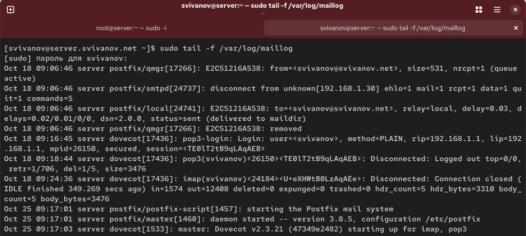

Запуск мониторинга

## Настройка LMTP в Dovecote

Добавим в список протоколов, с которыми может работать Dovecot, протокол LMTP. (рис. 2).

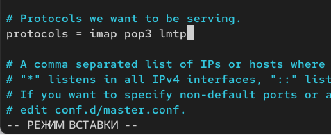

Список протоколов с которыми может работать Dovecot

## Настройка LMTP в Dovecote

Настроим в Dovecot сервис lmtp для связи с Postfix в файле /etc/dovecot/conf.d/10-master.conf. (рис. 3)

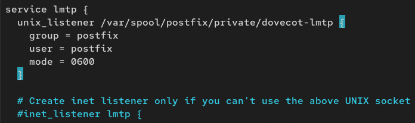

Настройка lmtp Для связи с Postfix

## Настройка LMTP в Dovecote

В файле /etc/dovecot/conf.d/10-auth.conf зададим формат имени пользователя для аутентификации в форме логина пользователя без указания домена (рис. 5)

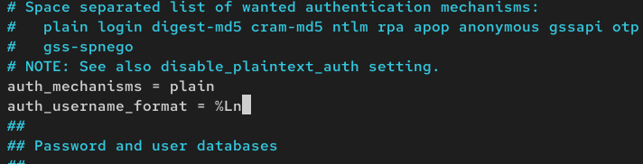

Задание формата имени пользователя

## Настройка LMTP в Dovecote

Просмотрим мониторинг почты. (рис. 7)

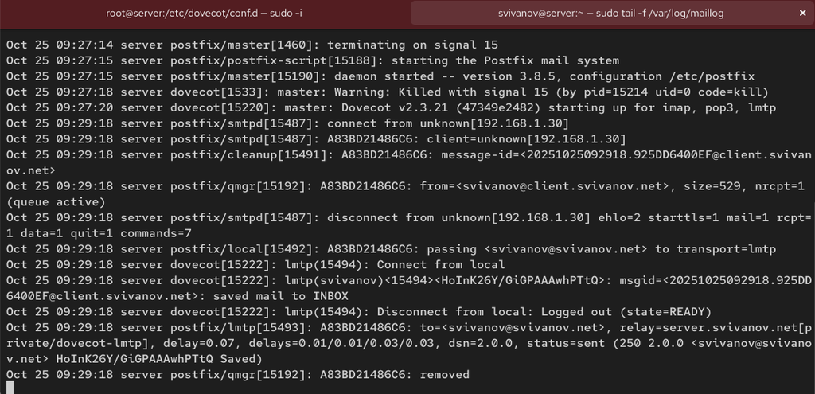

Просмотр мониторинга

## Настройка LMTP в Dovecote

На сервере просмотрим почтовый ящик пользователя: (рис. 8)

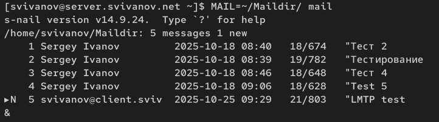

Просмотр ящика на сервере

## Настройка SMTP-аутентификации

В файле /etc/dovecot/conf.d/10-master.conf определим службу аутентификации пользователей: (рис. 9)

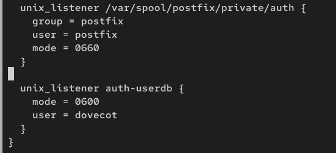

Определение службы аутентификации пользователей

## Настройка SMTP-аутентификации

Для Postfix зададим тип аутентификации SASL для smtpd и путь к соответствующему unix-сокету: (рис. 10)

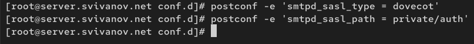

Тип аутентификации и путь к сокету

## Настройка SMTP-аутентификации

Настроим Postfix для приёма почты из Интернета только для обслуживаемых нашим сервером пользователей или для произвольных пользователей локальной машины. (рис. 11)

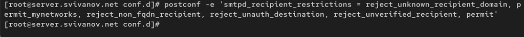

Настройка Postfix для приема почты

## Настройка SMTP-аутентификации

В настройках Postfix ограничим приём почты только локальным адресом SMTPсервера сети: (рис. 12)

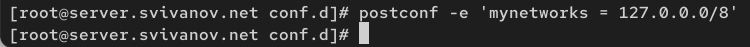

Ограничение приема почты

## Настройка SMTP-аутентификации

Для проверки работы аутентификации временно запустим SMTP-сервер (порт 25) с возможностью аутентификации. (рис. 13)

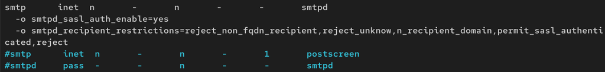

Редактирование master.cf

## Настройка SMTP-аутентификации

Перезапустим Postfix и Dovecot (рис. 14)

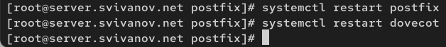

Перезапуск сервисов

## Настройка SMTP-аутентификации

На клиенте установим telnet: (рис. 15)

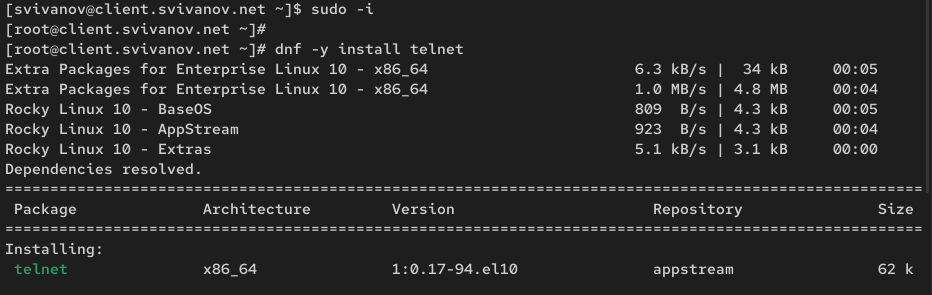

Установка telnet на клиенте

## Настройка SMTP-аутентификации

На клиенте получим строку для аутентификации (рис. 16)

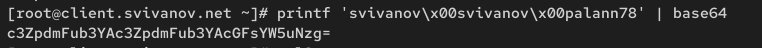

Получение строки для аутентификации

## Настройка SMTP-аутентификации

Подключимся на клиенте к SMTP-серверу посредством telnet: (рис. 17)

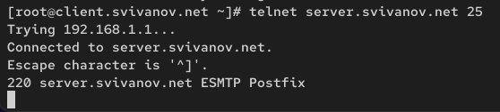

Подключение к SMTP

## Настройка SMTP-аутентификации

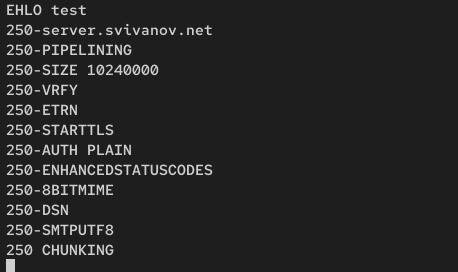

Тестирование соединения

## Настройка SMTP-аутентификации

Проверим авторизацию, задав: (рис. 19)

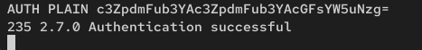

Проверка авторизации

## Настройка SMTP over TLS

Настроим на сервере TLS, воспользовавшись временным сертификатом Dovecot. (рис. 20)

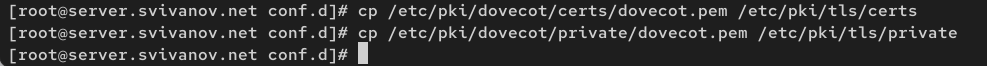

Копируем файлы сертификата

## Настройка SMTP over TLS

Сконфигурируем Postfix, указав пути к сертификату и ключу, а также к каталогу для хранения TLS-сессий и уровень безопасности: (рис. 21)

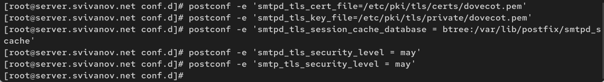

Конфигурация Postfix

## Настройка SMTP over TLS

Редактируем master.cf для того чтобы запустить SMTP-сервер на 587-м порту (рис. 22)

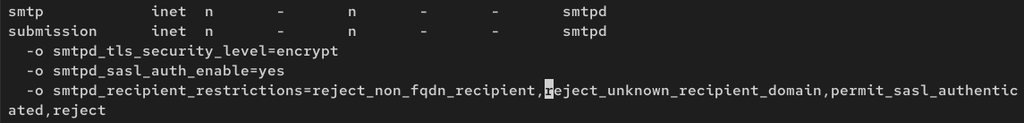

Редактирование master.cf

## Настройка SMTP over TLS

Настроим межсетевой экран, разрешив работать службе smtp-submission: (рис. 23)

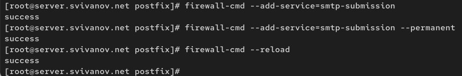

Настройка firewall

## Настройка SMTP over TLS

Перезапустим Postfix: (рис. 24)

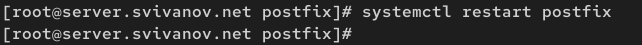

перезапуск Postfix

## Настройка SMTP over TLS

На клиенте подключимся к SMTP-серверу через 587-й порт посредством openssl (рис. 25)

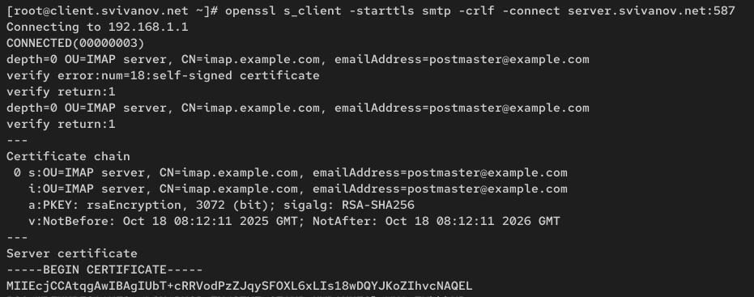

Подключение к SMTP на клиенте

## Настройка SMTP over TLS

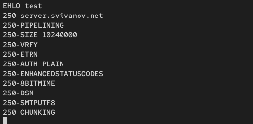

Тестирование подключения

## Настройка SMTP over TLS

Проверим аутентификацию: (рис. 27)

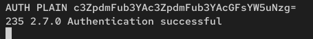

Проверка аутентификации

## Настройка SMTP over TLS

Проверим корректность отправки почтовых сообщений с клиента (рис. 28)

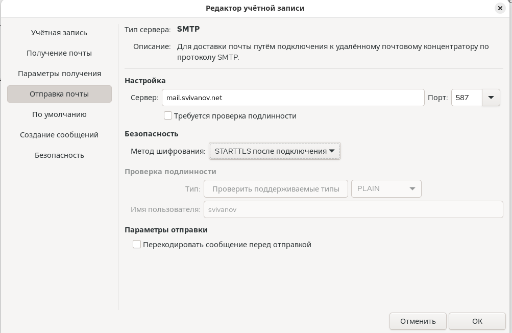

Редактирование настроек учетной записи

## Настройка SMTP over TLS

Отправим письмо. (рис. 29)

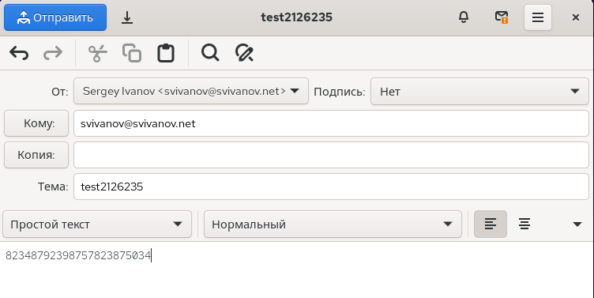

Отправка письма

## Настройка SMTP over TLS

Видим, что письмо доставлено. (рис. 30)

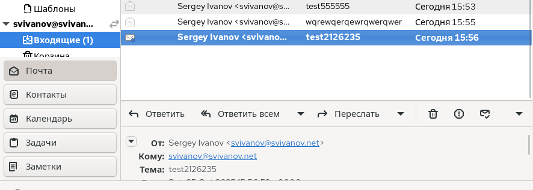

Полученное письмо

## Внесение изменений в настройки внутреннего окружения виртуальной машины

На машине server перейдем в каталог для внесения изменений. В соответствующие подкаталоги поместим конфигурационные файлы Dovecot и Postfix: (рис. 31)

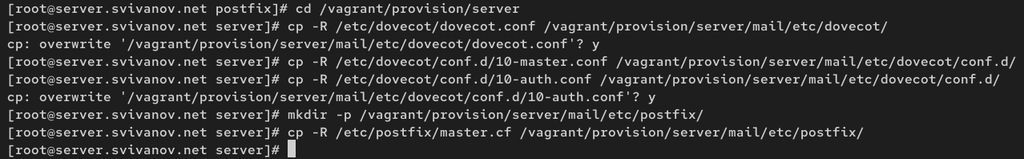

Замена конф. файлов

## Внесение изменений в настройки внутреннего окружения виртуальной машины

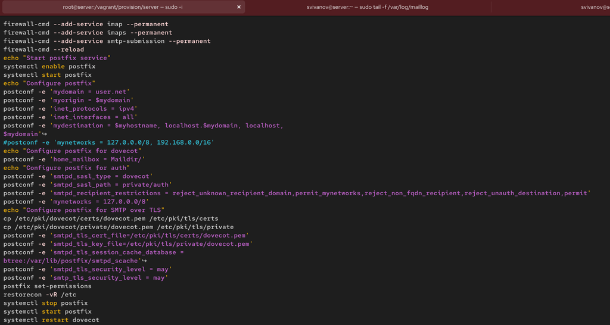

Коррекция скрипта

## Внесение изменений в настройки внутреннего окружения виртуальной машины

Внесем изменения в файл /vagrant/provision/client/mail.sh, добавив установку telnet. (рис. 33)

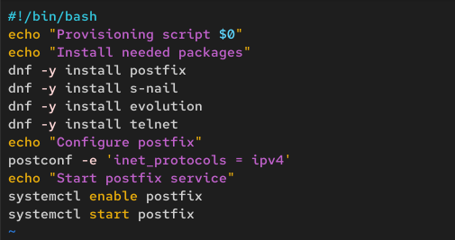

Коррекция скрипта

## Вывод

В ходе выполнения лабораторной работы мы приобрели приобрели практические навыки по конфигурированию SMTP-сервера в части настройки аутентификации.